# SWNE Walkthrough using Seurat

Yan Wu

11/12/2018

This is a quick walkthrough demonstrating how to generate SWNE plots alongside the [Seurat](http://satijalab.org/seurat/) pipeline using a [3k PBMC](https://support.10xgenomics.com/single-cell-gene-expression/datasets/1.1.0/pbmc3k) dataset as an example.

First let’s load the required libraries

```r
library(Seurat)
library(swne)
```

Next let’s load the Seurat object

```r
obj <- readRDS("~/swne/Data/pbmc3k_final.RObj")
```

Most scRNA-seq pipelines only use a subset of highly overdispersed genes for analysis. We’ll pull out those variable genes here, as well as the cluster labels.

```r
## Pull out overdispersed genes as defined by Seurat
var.genes <- VariableFeatures(obj)
length(var.genes)
```

```
## [1] 2000
```

```r
## Pull out cell clusters as defined by Seurat
cell.clusters <- Idents(obj)
levels(cell.clusters)
```

```
## [1] "Naive CD4 T"  "Memory CD4 T" "CD14+ Mono"   "B"
## [5] "CD8 T"        "FCGR3A+ Mono" "NK"           "DC"
## [9] "Mk"
```

The easiest way to generate an SWNE embedding is to use the wrapper function `RunSWNE`

```r
## Run SWNE
genes.embed <- c("MS4A1", "GNLY", "CD3E", "CD14",
                 "FCER1A", "FCGR3A", "LYZ", "PPBP", "CD8A")
swne.embedding <- RunSWNE(obj, k = 16, genes.embed = genes.embed, sample.groups = cell.clusters)
```

```
## [1] "2000 variable genes to use"
## Initial stress        : 0.12346
## stress after  10 iters: 0.03836, magic = 0.500
## stress after  20 iters: 0.03631, magic = 0.500
## stress after  30 iters: 0.03571, magic = 0.500
## stress after  40 iters: 0.03570, magic = 0.500
```

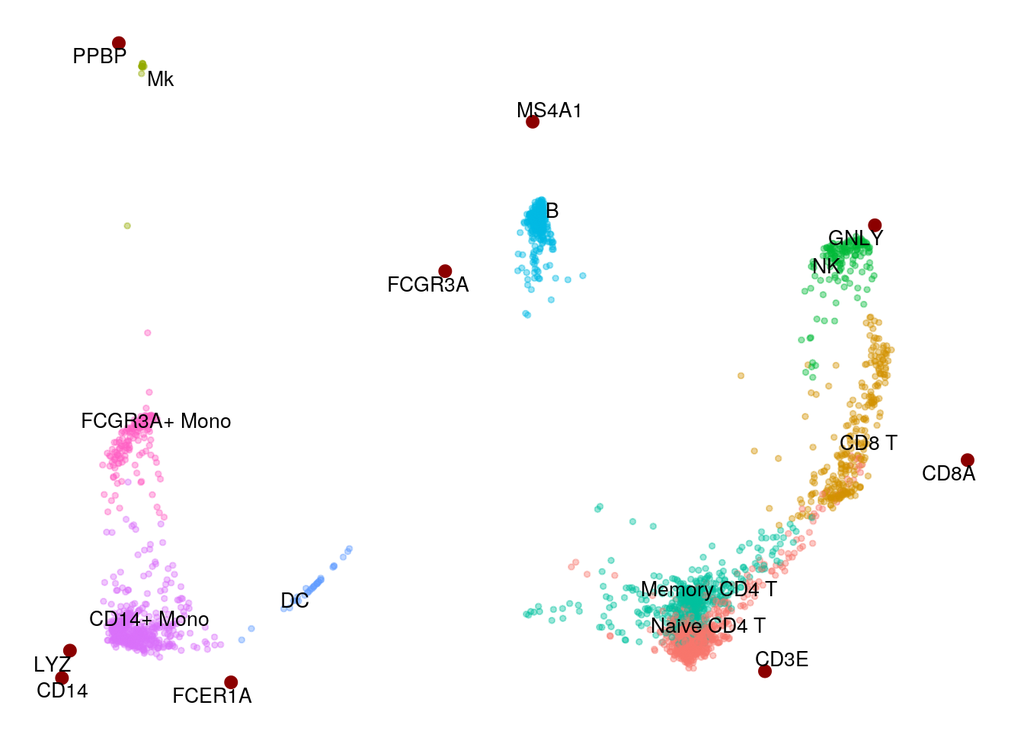

```r
## Plot SWNE
PlotSWNE(swne.embedding, alpha.plot = 0.4, sample.groups = cell.clusters,
         do.label = T, label.size = 3.5, pt.size = 1, show.legend = F,
         seed = 42)
```

`RunSWNE` can also return a Seurat object with SWNE set as a dimensional reduction

```r
## Run SWNE
obj <- RunSWNE(obj, k = 16, genes.embed = genes.embed,
               return.format = "seurat")
```

```
## [1] "2000 variable genes to use"
## Initial stress        : 0.12403
## stress after  10 iters: 0.05757, magic = 0.092
## stress after  20 iters: 0.03781, magic = 0.500
## stress after  30 iters: 0.03656, magic = 0.500
## stress after  40 iters: 0.03645, magic = 0.500
## stress after  50 iters: 0.03644, magic = 0.500
```

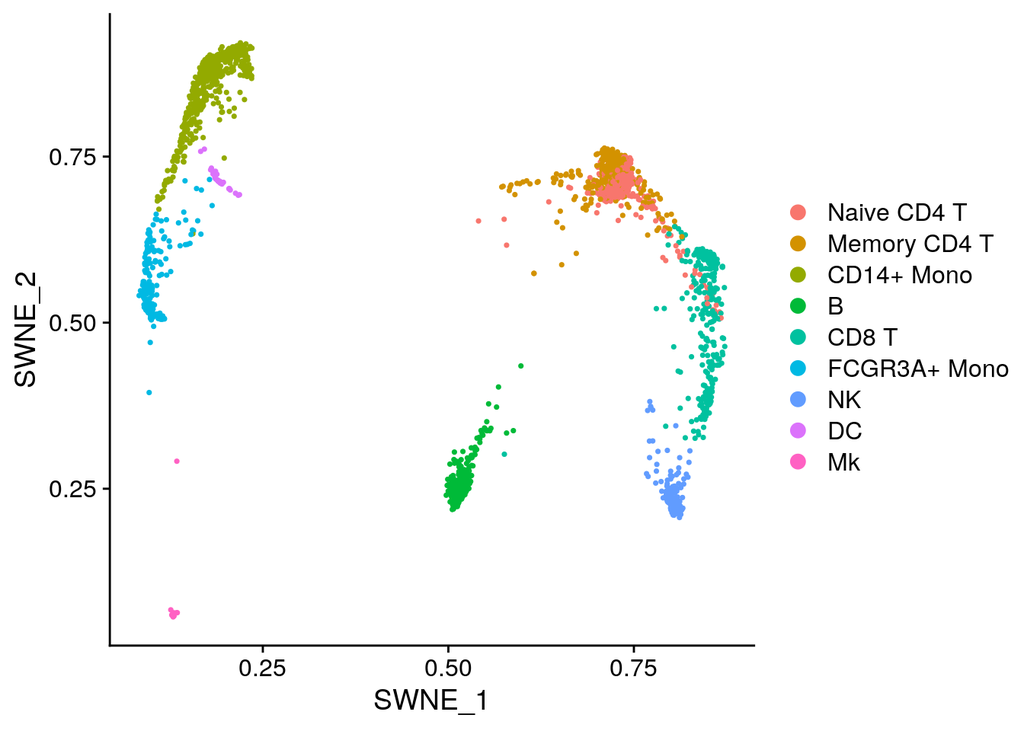

```r
DimPlot(obj, reduction = "swne")
```

Now we’ll go through the SWNE embedding process step by step to get a sense of how everything works

First, let’s pull out the counts, scale and adjust gene variance, while keeping the scaled matrix nonnegative.

```r
norm.counts <- ExtractNormCounts(obj, obj.type = "seurat", rescale = T, rescale.method = "log")
```

```
## calculating variance fit ... using gam
```

```r
dim(norm.counts)
```

```
## [1] 13714  2638
```

We use the `FindNumFactors` function to identify the optimal number of factors to use. This function can be slow for large datasets, since it iterates over different values of `k`, so a simple “hack” is to just set `k` equal to the number of significant principal components.

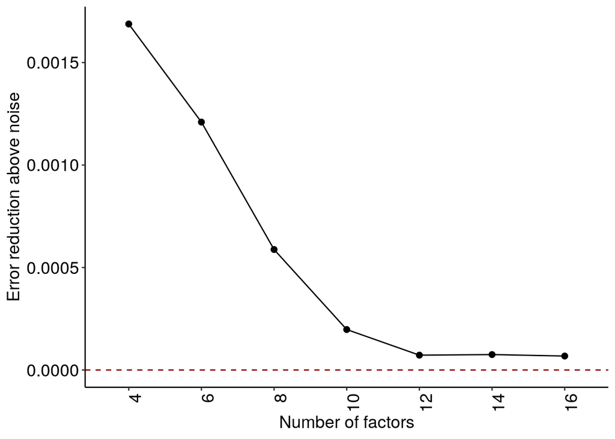

```r
k.range <- seq(2,16,2) ## Range of factors to iterate over
k.err <- FindNumFactors(norm.counts[var.genes,], k.range = k.range, n.cores = 8, do.plot = T)
```

We then run the NMF decomposition. We can initialize the NMF using either Independent Component Analysis (ica), Nonnegative SVD (nnsvd), or a completely random initialization. ICA is recommended for most datasets. The output of `RunNMF` is a list of the gene loadings (W) and NMF embedding (H).

```r
k <- 16
nmf.res <- RunNMF(norm.counts[var.genes,], k = k)
```

We can either use the pre-computed Shared Nearest Neighbors (SNN) matrix from Seurat or re-compute it ourselves.

```r
# pc.scores <- t(GetCellEmbeddings(se.obj, reduction.type = "pca", dims.use = 1:k))
# snn <- CalcSNN(pc.scores)
obj <- FindNeighbors(obj, k = 10, prune.SNN = 1/15)
```

```r
snn <- as(obj@graphs$RNA_snn, "dgCMatrix")
```

We can prune the SNN matrix by removing edges between cells in clusters that don’t share a statistically significant amount of edges using a PAGA graph (https://github.com/theislab/paga)

```r
knn <- as(obj@graphs$RNA_nn, "dgCMatrix") ## Extract kNN matrix
snn <- PruneSNN(snn, knn, clusters = cell.clusters, qval.cutoff = 1e-3)
```

Run the SWNE embedding. The three key parameters are `alpha.exp`, `snn.exp`, and `n_pull`, which control how the factors and neighboring cells affect the cell coordinates.

```r
alpha.exp <- 1.25 # Increase this > 1.0 to move the cells closer to the factors. Values > 2 start to distort the data.
snn.exp <- 0.25 # Lower this < 1.0 to move similar cells closer to each other
n_pull <- 3 # The number of factors pulling on each cell. Must be at least 3.
swne.embedding <- EmbedSWNE(nmf.res$H, SNN = snn, alpha.exp = alpha.exp, snn.exp = snn.exp,
                            n_pull = n_pull)
```

```
## Initial stress        : 0.15145
## stress after  10 iters: 0.04650, magic = 0.500
## stress after  20 iters: 0.04597, magic = 0.500
## stress after  30 iters: 0.04594, magic = 0.500
```

For now, let’s hide the factors by setting their names to the empty string `""`. We’ll interpret them later

```r
swne.embedding$H.coords$name <- ""
```

To help with interpreting these cell clusters, let’s pick some key PBMC genes to embed.

```r
genes.embed <- c("MS4A1", "GNLY", "CD3E", "CD14",
                 "FCER1A", "FCGR3A", "LYZ", "PPBP", "CD8A")
```

Since we only ran NMF on the overdispersed genes, we need to project the rest of the genes onto the NMF projection to get gene loadings for all genes.

```r
nmf.res$W <- ProjectFeatures(norm.counts, nmf.res$H, n.cores = 8)
```

Now we can embed the key PBMC genes onto the visualization and remake the plot

```r
swne.embedding <- EmbedFeatures(swne.embedding, nmf.res$W, genes.embed, n_pull = n_pull)
```

Let’s make the SWNE plot with the key genes embedded. The closer a cell or a cluster is to a gene, the higher the expression level. We set a seed for reproducible cluster colors, so that every plot will use the same colors to label the clusters.

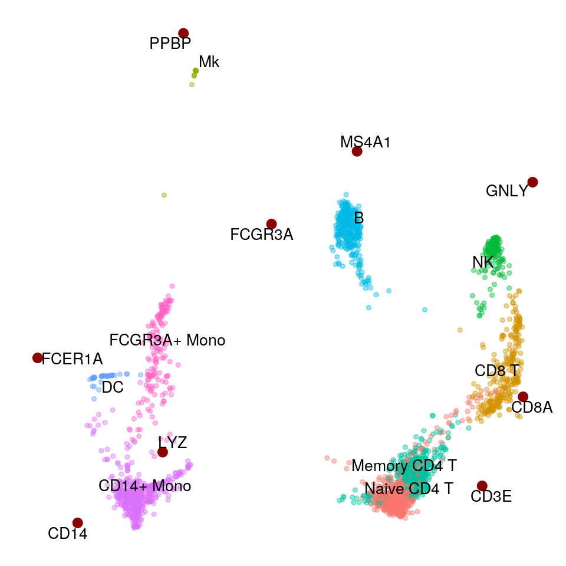

```r
color.seed <- 42
PlotSWNE(swne.embedding, alpha.plot = 0.4, sample.groups = cell.clusters, do.label = T,
         label.size = 3.5, pt.size = 1, show.legend = F, seed = color.seed)
```

We can validate the embedded genes by overlaying the expression of one of these key genes onto the plot.

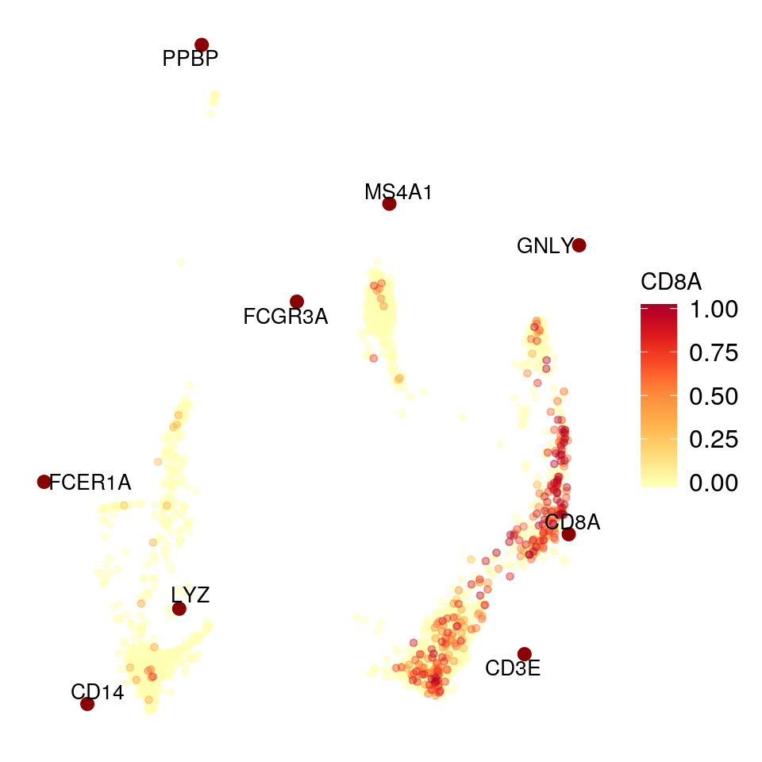

```r
gene.use <- "CD8A"
gene.expr <- norm.counts[gene.use,]
FeaturePlotSWNE(swne.embedding, gene.expr, gene.use, alpha.plot = 0.4, label.size = 3.5, pt.size = 1.25)
```

We can also make a t-SNE plot for comparison.

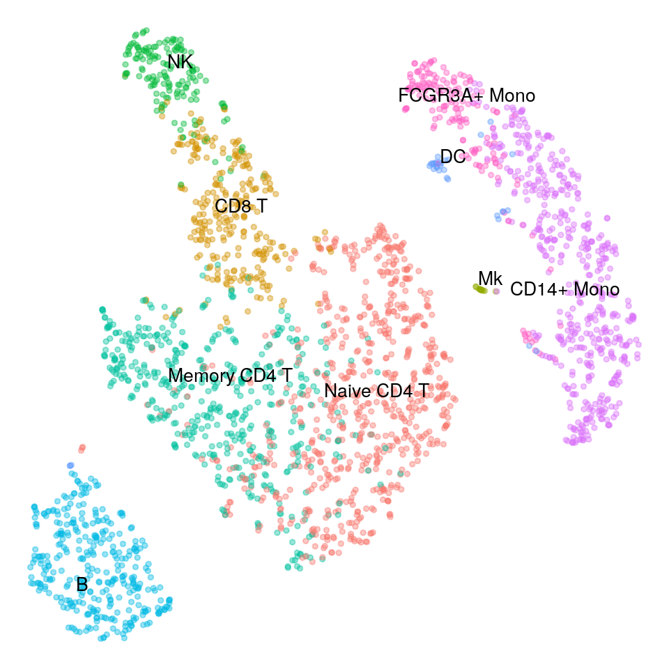

```r
obj <- RunTSNE(obj)
tsne.scores <- Embeddings(obj, "tsne")
PlotDims(tsne.scores, sample.groups = cell.clusters, pt.size = 1, label.size = 3.5, alpha = 0.4,
         show.legend = F, seed = color.seed, show.axes = F)
```

We can also interpret the factors by using the gene loadings matrix. Here, we extract the top 3 genes for each factor by gene loading. Since NMF tends to create a parts-based representation of the data, the factors often correspond to key biological processes or gene modules that explain the data.

```r
gene.loadings <- nmf.res$W
top.factor.genes.df <- SummarizeAssocFeatures(gene.loadings, features.return = 3)
head(top.factor.genes.df)
```

```
##   assoc_score feature   factor
## 1   0.7571037     LTB factor_1
## 2   0.5724399    FTH1 factor_1
## 3   0.5584401    IL32 factor_1
## 4   0.5369279    CD74 factor_2
## 5   0.4849361 HLA-DRA factor_2
## 6   0.4363460    FTH1 factor_2
```

And finally, we can make a heatmap to visualize the top factors for each gene

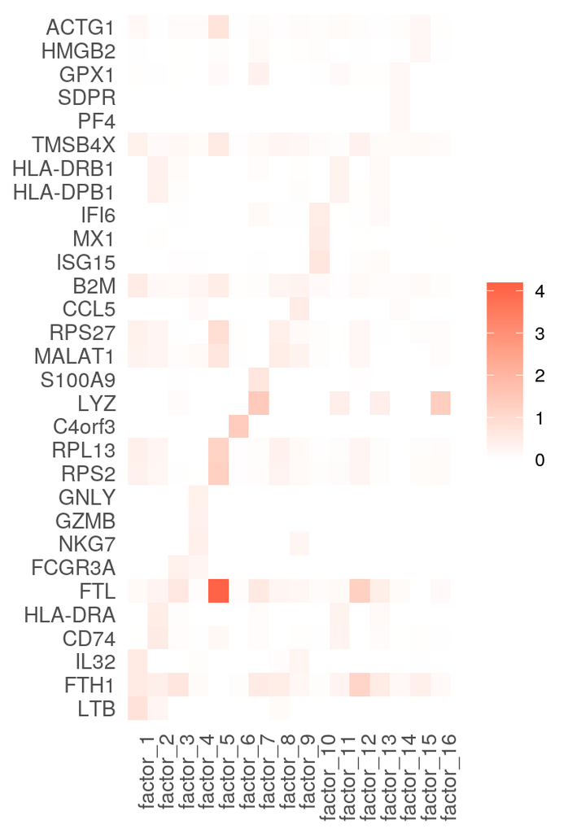

```r
gene.loadings.heat <- gene.loadings[unique(top.factor.genes.df$feature),]
ggHeat(gene.loadings.heat, clustering = "col")
```

Finally, we can extract cluster colors for compatibility with other plotting methods (i.e. Monocle)

```r
color.mapping <- ExtractSWNEColors(swne.embedding, sample.groups = cell.clusters, seed = color.seed)
color.mapping
```

```
## Memory CD4 T            B   CD14+ Mono           NK        CD8 T
##    "#00C19F"    "#00B9E3"    "#DB72FB"    "#00BA38"    "#D39200"
##  Naive CD4 T FCGR3A+ Mono           DC           Mk
##    "#F8766D"    "#FF61C3"    "#619CFF"    "#93AA00"
```